# CP03_Marcos_Barragan

Marcos Barragán

5/11/2020

Lo primero que haré será cargar los datos necesarios para la realización de la práctica. Las diferentes variables que se encuentran dentro del mismo son:

- `Overall` Science Score (average score for 15 year olds)
- `Issues`
- `Explain`
- `Evidence`
- `Interest` in science
- `Support` for scientific inquiry
- `Income` Index
- `Health` Index
- `Edu` Index
- `HDI`: Human Development Index (Compuesto a su vez por Income index, Health Index y Education Index)

Si hacemos una primera visualización de los mismos:

```
##      Country Overall Issues Explain Evidence Interest Support Income Health
## 1    Albania      NA     NA      NA       NA       NA      NA  0.599  0.886
## 2  Argentina     391    395     386      385      567     506  0.678  0.868
## 3  Australia     527    535     520      531      465     487  0.826  0.965
## 4    Austria     511    505     516      505      507     515  0.835  0.944
## 5 Azerbaijan     382    353     412      344      612     542  0.566  0.780
##     Edu   HDI
## 1 0.716 0.724
## 2 0.786 0.773
## 3 0.978 0.920
## 4 0.824 0.866
## 5    NA    NA
```

Vemos que hay algunas columnas con NA. Se me ocurrieron dos soluciones para este problema de valores nulos:

- O bien quitar todas aquellas filas que contengan al menos un NA (con lo que nos estaríamos cargando un 20% de los datos)
- O bien filtrar de alguna manera las filas de países con algún NA.

Optando por la segunda finalmente, lo que haré será eliminar aquellas filas que contengan más datos NA que datos buenos. De esta manera, eliminaré del dataset los países: Albania, Kazakhstan, Panamá, Perú, Shangai-China, Singapur, Trinidad y Tobago, y los Emiratos Árabes Unidos. El resto de países que contienen valores NA los sustituiré por la media de los datos de la columna en la que se encuentren. Esto nos beneficia, pues no perdemos tantos elementos del dataset como hubiera ocurrido al eliminar “a lo bruto” todos los datos NA del mismo.

```r
datos <- datos[-c(1, 29, 42, 43, 50, 51, 59, 62), ]

datos <- na_mean(datos)

head(datos, 5)
```

```
##      Country Overall Issues Explain Evidence Interest Support Income Health
## 2  Argentina     391    395     386      385      567     506  0.678  0.868
## 3  Australia     527    535     520      531      465     487  0.826  0.965
## 4    Austria     511    505     516      505      507     515  0.835  0.944
## 5 Azerbaijan     382    353     412      344      612     542  0.566  0.780
## 6    Belgium     510    515     503      516      503     492  0.831  0.935
##         Edu       HDI
## 2 0.7860000 0.7730000
## 3 0.9780000 0.9200000
## 4 0.8240000 0.8660000
## 5 0.8096923 0.8128077
## 6 0.8680000 0.8770000
```

Podemos averiguar algo más de las propiedades estadísticas de los datos con los que estamos tratando al ejecutar el comando *skim* sobre los mismos, que además nos esboza un pequeño histograma con la distribución de los datos.

```r
skim(datos)
```

Data summary

| Name | datos |
| --- | --- |
| Number of rows | 57 |
| Number of columns | 11 |
| _______________________ |  |
| Column type frequency: |  |
| character | 1 |
| numeric | 10 |
| ________________________ |  |
| Group variables | None |

**Variable type: character**

| skim_variable | n_missing | complete_rate | min | max | empty | n_unique | whitespace |
| --- | --- | --- | --- | --- | --- | --- | --- |
| Country | 0 | 1 | 5 | 24 | 0 | 57 | 0 |

**Variable type: numeric**

| skim_variable | n_missing | complete_rate | mean | sd | p0 | p25 | p50 | p75 | p100 | hist |
| --- | --- | --- | --- | --- | --- | --- | --- | --- | --- | --- |
| Overall | 0 | 1 | 473.14 | 54.58 | 322.00 | 428.00 | 489.00 | 513.00 | 563.00 | ▁▃▂▇▅ |
| Issues | 0 | 1 | 469.91 | 53.93 | 321.00 | 427.00 | 489.00 | 514.00 | 555.00 | ▁▃▂▇▆ |
| Explain | 0 | 1 | 475.02 | 54.02 | 334.00 | 432.00 | 490.00 | 517.00 | 566.00 | ▁▃▂▇▃ |
| Evidence | 0 | 1 | 469.81 | 61.74 | 288.00 | 423.00 | 489.00 | 515.00 | 567.00 | ▁▂▃▇▆ |
| Interest | 0 | 1 | 528.16 | 49.84 | 448.00 | 501.00 | 522.00 | 565.00 | 644.00 | ▆▇▅▃▂ |
| Support | 0 | 1 | 512.18 | 26.08 | 447.00 | 494.00 | 512.00 | 529.00 | 569.00 | ▂▅▇▆▂ |
| Income | 0 | 1 | 0.75 | 0.11 | 0.41 | 0.68 | 0.76 | 0.83 | 0.94 | ▁▂▆▇▅ |
| Health | 0 | 1 | 0.89 | 0.06 | 0.74 | 0.84 | 0.91 | 0.94 | 0.99 | ▂▃▆▇▇ |
| Edu | 0 | 1 | 0.81 | 0.11 | 0.54 | 0.76 | 0.81 | 0.88 | 0.99 | ▂▃▇▇▆ |
| HDI | 0 | 1 | 0.81 | 0.08 | 0.58 | 0.76 | 0.82 | 0.88 | 0.94 | ▁▂▆▇▇ |

Si representamos las diferentes variables del dataset frente a la variable target `Overall` sobre la que queremos llevar a cabo el estudio, podremos estimar el comportamiento de las mismas entre ellas y para con el target.

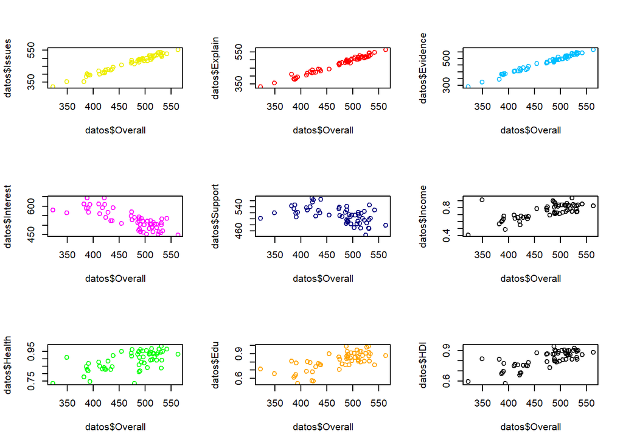

```r
par(mfrow = c(3,3))

plot(datos$Overall, datos$Issues, col = 'Yellow2')
plot(datos$Overall, datos$Explain, col = 'Red')
plot(datos$Overall, datos$Evidence, col = 'Deepskyblue')
plot(datos$Overall, datos$Interest, col = 'Magenta')
plot(datos$Overall, datos$Support, col = 'Navy')
plot(datos$Overall, datos$Income, col = 'Black')
plot(datos$Overall, datos$Health, col = 'Green')
plot(datos$Overall, datos$Edu, col = 'Orange')
plot(datos$Overall, datos$HDI, col = 'Grey2')
```

A la vista de las gráficas, podemos comprobar que el comportamiento de la variable `Overall` es lineal con `Issues`, con `Explain` y con `Evidence`. No obstante, en el enunciado nos dicen que las variables clave (las que deberíamos utilizar) y estas tres anteriores no están entre ellas, por lo que, de aquí en adelante, prescindiré de ellas y me centraré en las demás columnas.

A continuación estimaré unos modelos de ajuste sobre `Overall` del resto de variables, con el fin de obtener el mejor modelo de ajuste para cada una de ellas y estimar, además, el número de grados de libertad que deberíamos considerar en cada uno de los modelos. Esto lo implementaré a partir de la función *smooth.spline* que se encuentra dentro del paquete *gvcm*. Este método lleva a cabo una serie de cross validations en su interior, que es lo que le permite discernir entre los mejores parámetros para cada modelo de ajuste.

```r
interest_overall <- smooth.spline(datos$Interest, datos$Overall, cv = TRUE)
interest_overall
```

```
## Call:
## smooth.spline(x = datos$Interest, y = datos$Overall, cv = TRUE)
##
## Smoothing Parameter  spar= 0.921986  lambda= 0.003329385 (13 iterations)
## Equivalent Degrees of Freedom (Df): 5.011695
## Penalized Criterion (RSS): 47738.48
## PRESS(l.o.o. CV): 1033.905
```

```r
support_overall <- smooth.spline(datos$Support, datos$Overall, cv = TRUE)
support_overall
```

```
## Call:
## smooth.spline(x = datos$Support, y = datos$Overall, cv = TRUE)
##
## Smoothing Parameter  spar= 1.499943  lambda= 124.7468 (28 iterations)
## Equivalent Degrees of Freedom (Df): 2.000756
## Penalized Criterion (RSS): 68397.24
## PRESS(l.o.o. CV): 2286.342
```

```r
income_overall <- smooth.spline(datos$Income, datos$Overall, cv = TRUE)
income_overall
```

```
## Call:
## smooth.spline(x = datos$Income, y = datos$Overall, cv = TRUE)
##
## Smoothing Parameter  spar= 1.098027  lambda= 0.006630564 (12 iterations)
## Equivalent Degrees of Freedom (Df): 4.200845
## Penalized Criterion (RSS): 54122.16
## PRESS(l.o.o. CV): 1234.68
```

```r
health_overall <- smooth.spline(datos$Health, datos$Overall, cv = TRUE)
health_overall
```

```
## Call:
## smooth.spline(x = datos$Health, y = datos$Overall, cv = TRUE)
##
## Smoothing Parameter  spar= 1.499948  lambda= 40.36844 (25 iterations)
## Equivalent Degrees of Freedom (Df): 2.002841
## Penalized Criterion (RSS): 94388.77
## PRESS(l.o.o. CV): 1948.28
```

```r
edu_overall <- smooth.spline(datos$Edu, datos$Overall, cv = TRUE)
edu_overall
```

```
## Call:
## smooth.spline(x = datos$Edu, y = datos$Overall, cv = TRUE)
##
## Smoothing Parameter  spar= 1.019507  lambda= 0.005975507 (14 iterations)
## Equivalent Degrees of Freedom (Df): 4.439724
## Penalized Criterion (RSS): 58037.35
## PRESS(l.o.o. CV): 1508.94
```

```r
HDI_overall <- smooth.spline(datos$HDI, datos$Overall, cv = TRUE)
HDI_overall
```

```
## Call:
## smooth.spline(x = datos$HDI, y = datos$Overall, cv = TRUE)
##
## Smoothing Parameter  spar= 1.499946  lambda= 29.11558 (26 iterations)
## Equivalent Degrees of Freedom (Df): 2.003397
## Penalized Criterion (RSS): 54535.27
## PRESS(l.o.o. CV): 1362.365
```

```r
kable(cbind(interest_overall$df, support_overall$df, income_overall$df, health_overall$df, edu_overall$df, HDI_overall$df),
      col.names = c('df interest', 'df support', 'df income', 'df health','df edu','df HDI'))
```

| df interest | df support | df income | df health | df edu | df HDI |
| --- | --- | --- | --- | --- | --- |
| 5.011695 | 2.000756 | 4.200845 | 2.002842 | 4.439724 | 2.003397 |

```r
#Si los redondeamos:

kable(cbind(round(interest_overall$df, 0), round(support_overall$df,0), round(income_overall$df, 0), round(health_overall$df, 0), round(edu_overall$df, 0), round(HDI_overall$df,0)), col.names = c('df interest', 'df support', 'df income', 'df health','df edu','df HDI'))
```

| df interest | df support | df income | df health | df edu | df HDI |
| --- | --- | --- | --- | --- | --- |
| 5 | 2 | 4 | 2 | 4 | 2 |

Vemos que, en general, no son valores muy altos.

Una vez hecho lo anterior, pasaré a desarrollar un análisis de ajuste de las variables a través del uso de splines mediante un modelo GAM aditivo. En un primer modelo, incluiré splines en todas las variables clave que nos indican en el enunciado.

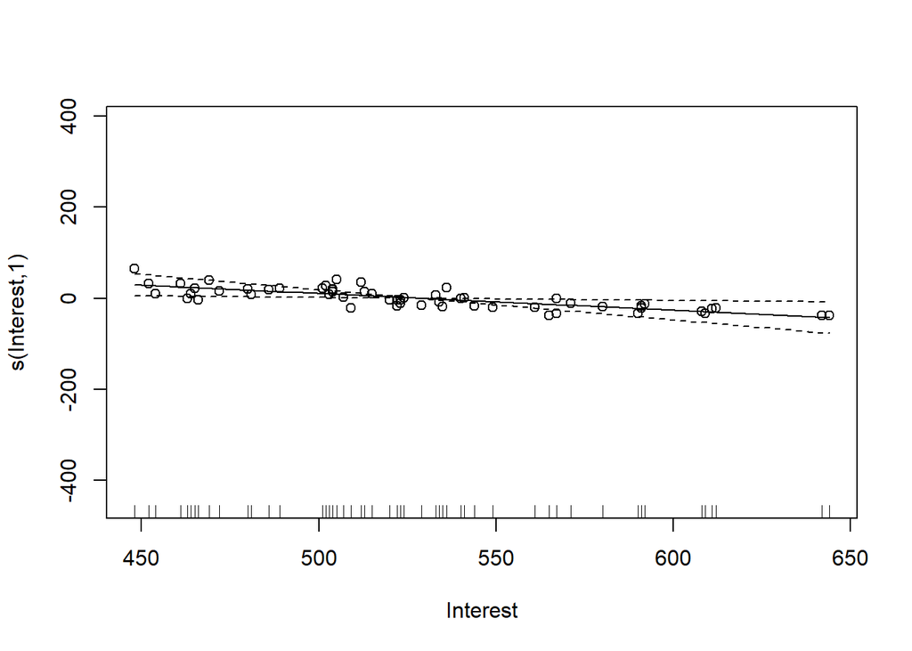

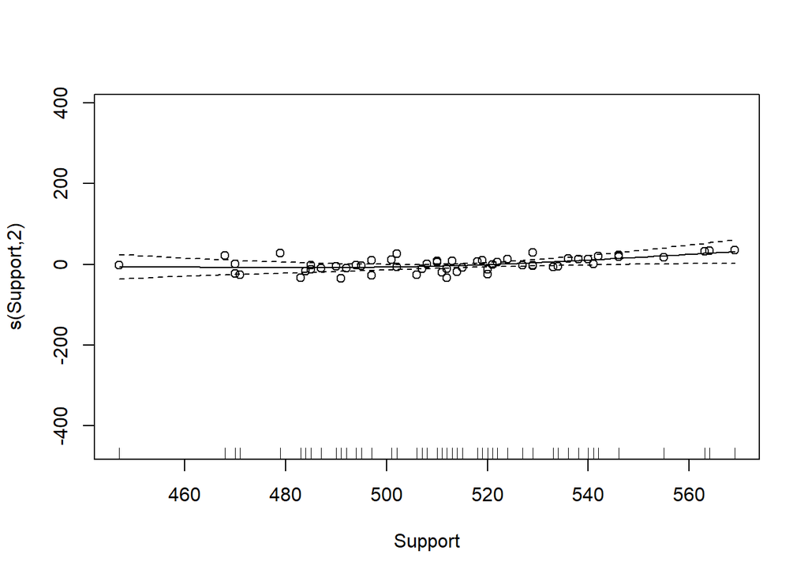

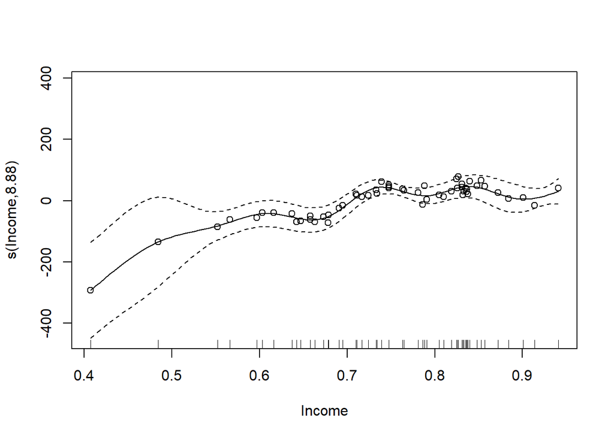

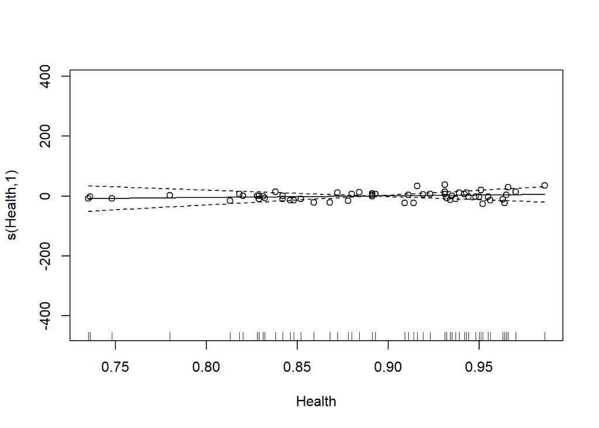

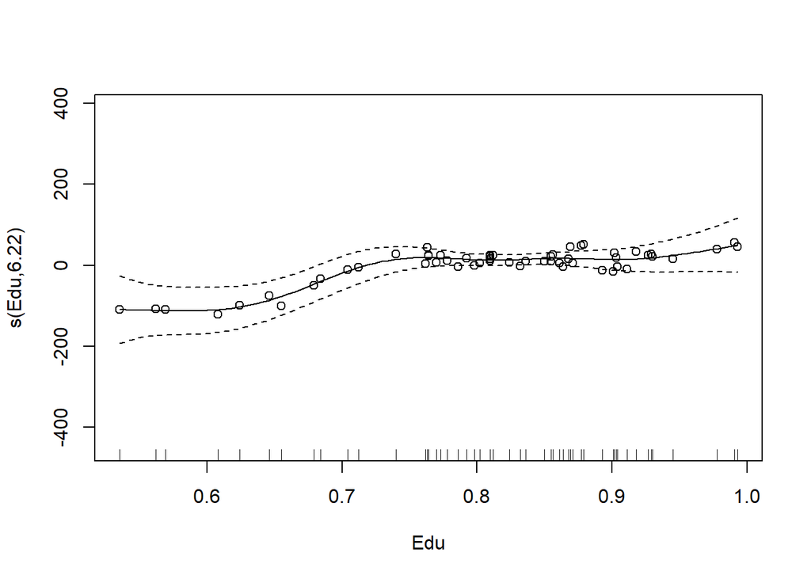

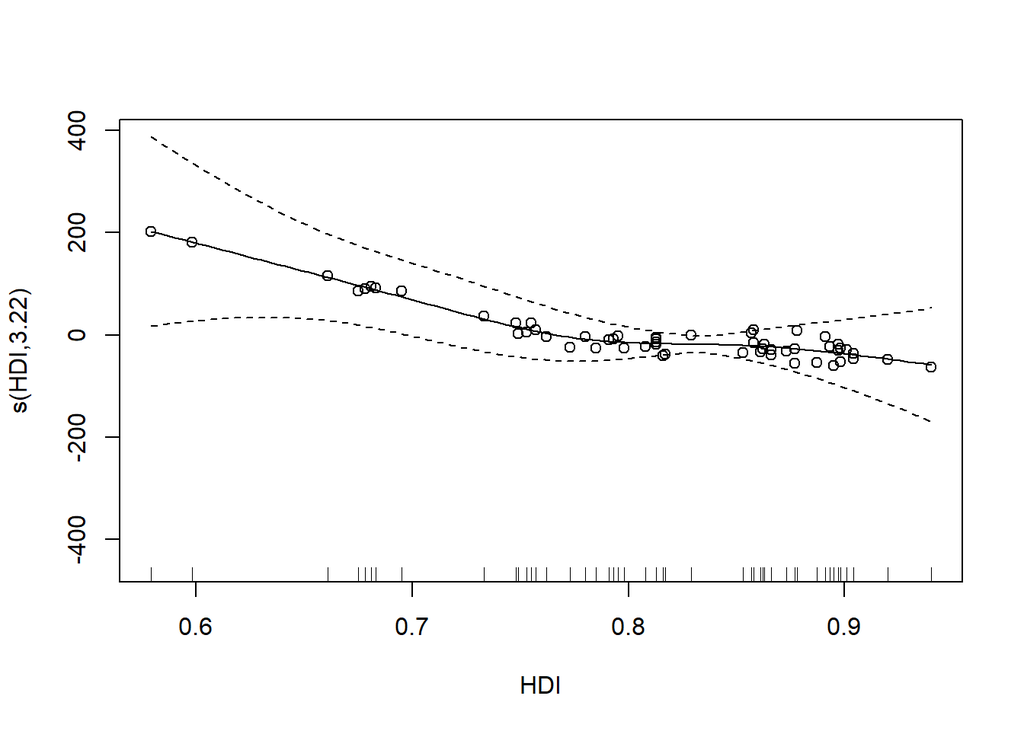

```r
modelo_splines <- gam(Overall ~ s(Interest) + s(Support) + s(Income) + s(Health) + s(Edu) + s(HDI), data = datos)

plot(modelo_splines, residuals = TRUE, pch = 1)
```

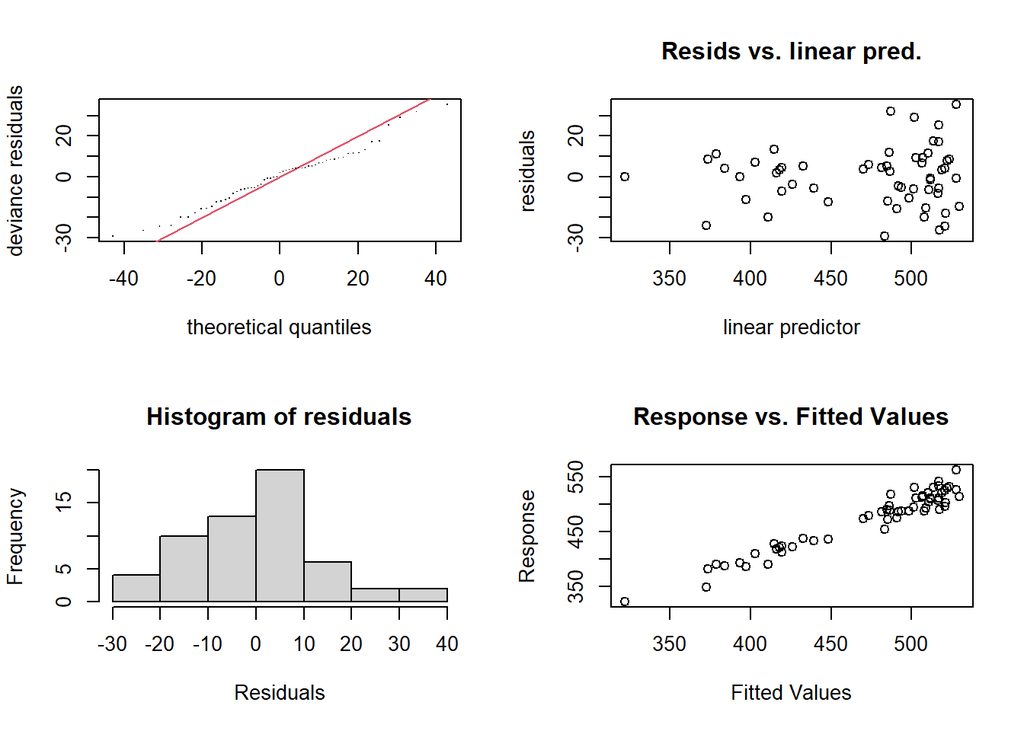

```
##
## Method: GCV   Optimizer: magic
## Smoothing parameter selection converged after 26 iterations.
## The RMS GCV score gradient at convergence was 1.31995e-05 .
## The Hessian was positive definite.
## Model rank =  55 / 55
##
## Basis dimension (k) checking results. Low p-value (k-index<1) may
## indicate that k is too low, especially if edf is close to k'.
##
##               k'  edf k-index p-value
## s(Interest) 9.00 1.00    0.93    0.28
## s(Support)  9.00 2.00    1.24    0.91
## s(Income)   9.00 8.88    1.14    0.76
## s(Health)   9.00 1.00    0.91    0.23
## s(Edu)      9.00 6.22    1.04    0.54
## s(HDI)      9.00 3.22    1.36    1.00
```

```r
gam.check(modelo_splines)
```

Una vez hecho el primer modelo general, con splines en todas las variables, podemos pasar a hacer un segundo modelo en el que estimemos diferentes consideraciones en el ajuste de las variables. Si estudiamos el comportamiento del ajuste tipo gam para cada variable de las que hemos incluido anteriormente, veremos algo como:

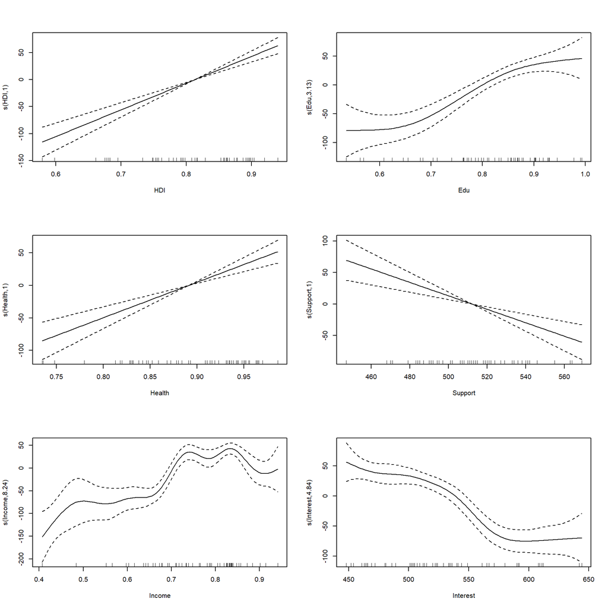

```r
par(mfrow = c(3,2))

plot(gam(Overall ~ s(HDI), data = datos))
plot(gam(Overall ~ s(Edu), data = datos ))
plot(gam(Overall ~ s(Health), data = datos))
plot(gam(Overall ~ s(Support), data = datos))
plot(gam(Overall ~ s(Income), data = datos ))
plot(gam(Overall ~ s(Interest), data = datos))
```

De las gráficas vemos que el comportamiento del ajuste de las variables `Health`, `Support` y `HDI` es prácticamente lineal. Teniendo esto en cuenta, lo que haré para estimar este segundo modelo, será eliminar los ajustes con splines para esas tres variables (por ahorrar también coste computacional). De esta manera, el segundo modelo será:

```r
modelo_sin_splines <- gam(Overall ~ s(Interest) + Support + s(Income) + Health + s(Edu) + HDI, data = datos)

modelo_sin_splines
```

```
##
## Family: gaussian
## Link function: identity
##
## Formula:
## Overall ~ s(Interest) + Support + s(Income) + Health + s(Edu) +
##     HDI
##
## Estimated degrees of freedom:
## 6.07 8.76 5.89  total = 24.71
##
## GCV score: 573.1494
```

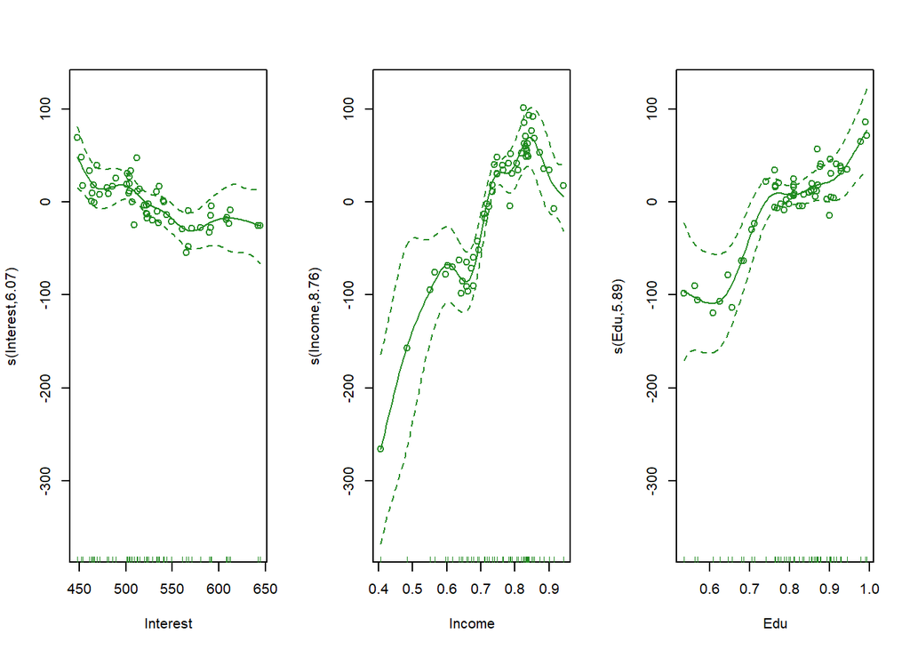

```r
par(mfrow = c(1, 3))
plot(modelo_sin_splines, residuals = TRUE, pch = 1, col =  'forestgreen')
```

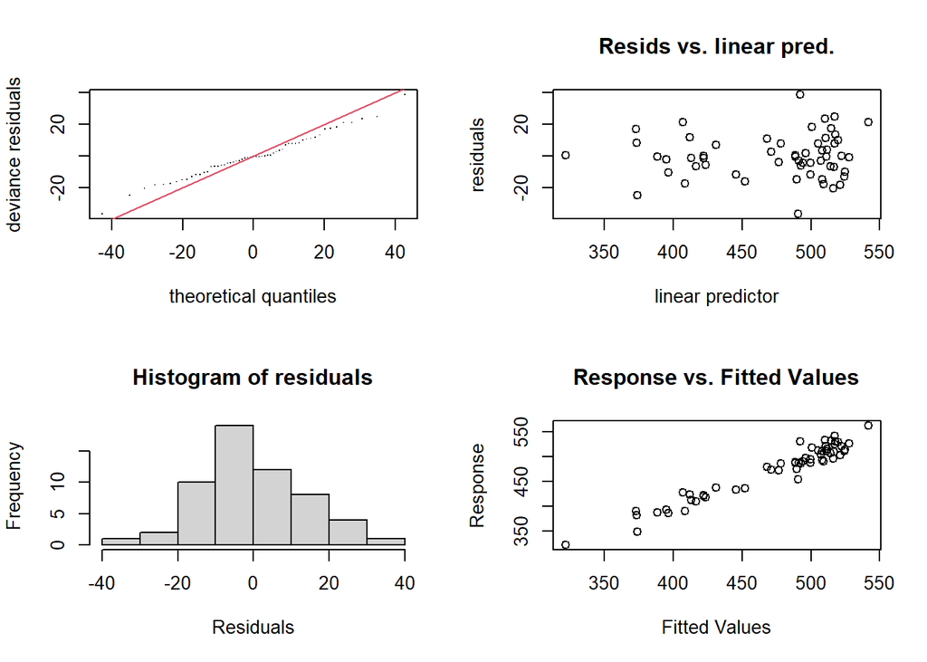

```
##
## Method: GCV   Optimizer: magic
## Smoothing parameter selection converged after 11 iterations.
## The RMS GCV score gradient at convergence was 0.001034464 .
## The Hessian was positive definite.
## Model rank =  31 / 31
##
## Basis dimension (k) checking results. Low p-value (k-index<1) may
## indicate that k is too low, especially if edf is close to k'.
##
##               k'  edf k-index p-value
## s(Interest) 9.00 6.07    1.16    0.84
## s(Income)   9.00 8.76    1.22    0.96
## s(Edu)      9.00 5.89    1.10    0.70
```

```r
gam.check(modelo_sin_splines)
```

Otro modelo podría salir de especificarle a aquellas variables que he dejado con spline los grados de libertad redondeados que he obtenido en el paso del *smooth.spline* (que son los óptimos para cada ajuste). En este caso:

- `Interest`: 5
- `Income`: 4
- `Edu`: 4

Con esto, tendremos:

He tenido que cargar la librería *gam* porque si no me daba problemas a la hora de evaluar un modelo introduciendo manualmente los grados de libertad.

```r
modelo_df_manuales <- gam::gam(Overall ~ s(Interest, df = 5) + Support + s(Income, df = 4) + Health + s(Edu, df = 4) + HDI, data = datos)

modelo_df_manuales
```

```
## Call:
## gam::gam(formula = Overall ~ s(Interest, df = 5) + Support +
##     s(Income, df = 4) + Health + s(Edu, df = 4) + HDI, data = datos)
##
## Degrees of Freedom: 56 total; 40.00001 Residual
## Residual Deviance: 23687.93
```

Tras haber desarrollado esos dos modelos, estimaré un modelo más, consistente en incluir ajustes polinómicos a las variables. Para ello:

- Estudiaré los diferentes ajustes polinómicos de las variables.
- Estimaré los errores asociados a cada uno de ellos.
- Finalmente, me quedaré con aquel modelo con menor error de ajuste asociado.

Esto es:

1. `Income`: en esta variable, nos vamos a encontrar que el polinomio de ajuste que menor error cometería sería el de grado 2. No obstante, el error entre el de grado 1 y el de grado 2 es similar, por lo que podríamos quedarnos con el de primer grado.

```r
cv.error <- rep(NA, 5)
rss <- rep(NA, 5)

for (i in 1:5) {

        modelo.poli <- glm(Overall ~ poly(Income, i), data = datos)
        cv.error[i] <- cv.glm(datos, modelo.poli)$delta[1]
        rss[i] <- sum(modelo.poli$residuals^2)

}

which.min(cv.error)
```

```
## [1] 2
```

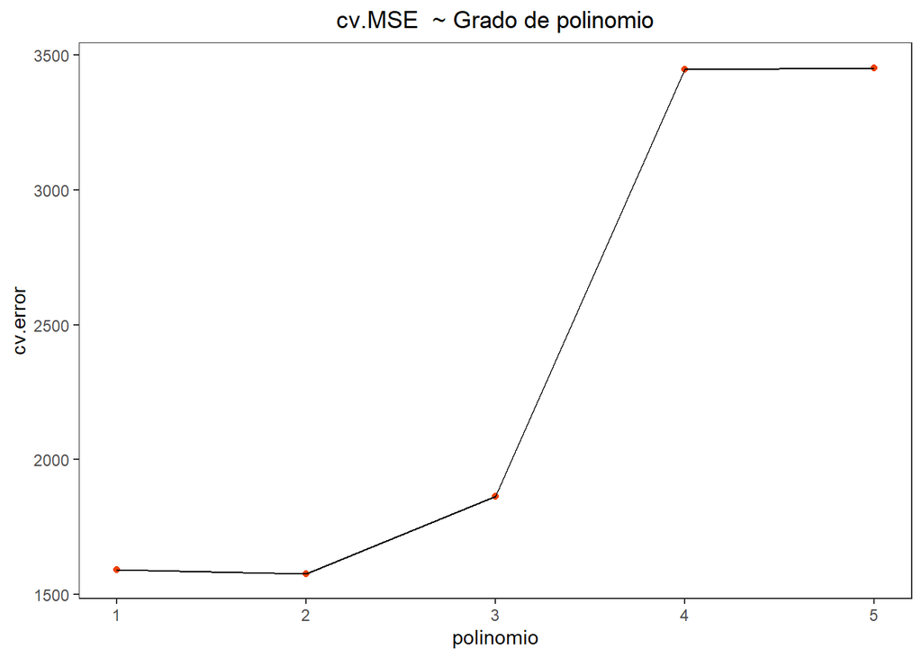

```r
ggplot(data = data.frame(polinomio = 1:5, cv.error = cv.error),
        aes(x = polinomio, y = cv.error)) +

        geom_point(color = "orangered2") +
        geom_path() +
        scale_x_continuous(breaks = 0:5) +
        labs(title = "cv.MSE  ~ Grado de polinomio") +
        theme_bw() +
        theme(panel.background = element_blank(), panel.grid.major = element_blank(), panel.grid.minor = element_blank()) +
        theme(plot.title = element_text(hjust = 0.5))
```

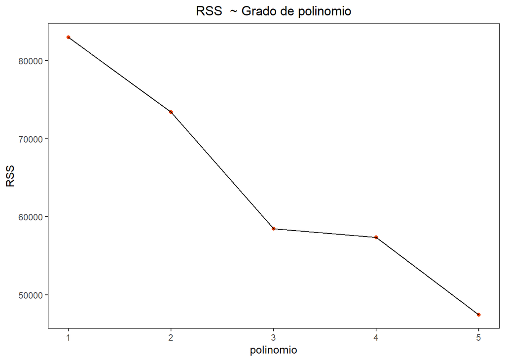

```r
ggplot(data = data.frame(polinomio = 1:5, RSS = rss),
       aes(x = polinomio, y = RSS)) +

     geom_point(color = "orangered2") +
     geom_path() +
     scale_x_continuous(breaks = 0:5) +
     labs(title = "RSS  ~ Grado de polinomio") +
     theme_bw() +
     theme(panel.background = element_blank(), panel.grid.major = element_blank(), panel.grid.minor = element_blank()) +
     theme(plot.title = element_text(hjust = 0.5))
```

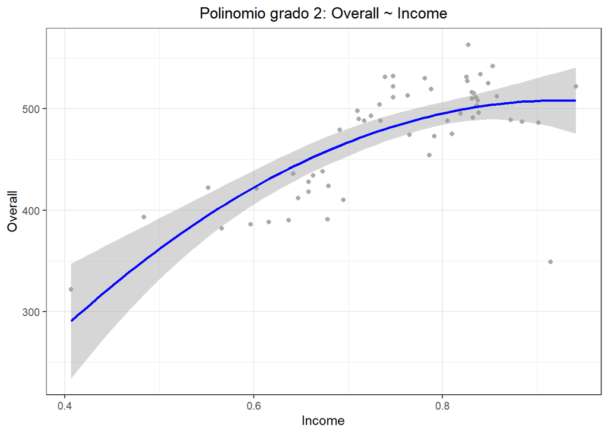

```r
ggplot(data = datos, aes(x = Income, y = Overall)) +
     geom_point(col = "darkgrey") +
     geom_smooth(method = "lm", formula = y ~ poly(x, 2), color = "blue", se = TRUE, level = 0.95) +
     labs(title = "Polinomio grado 2: Overall ~ Income") +
     theme_bw() + theme(plot.title = element_text(hjust = 0.5))
```

En las siguientes gráficas no mostraré el código, pues es una repetición del anterior.

2. `Interest`:

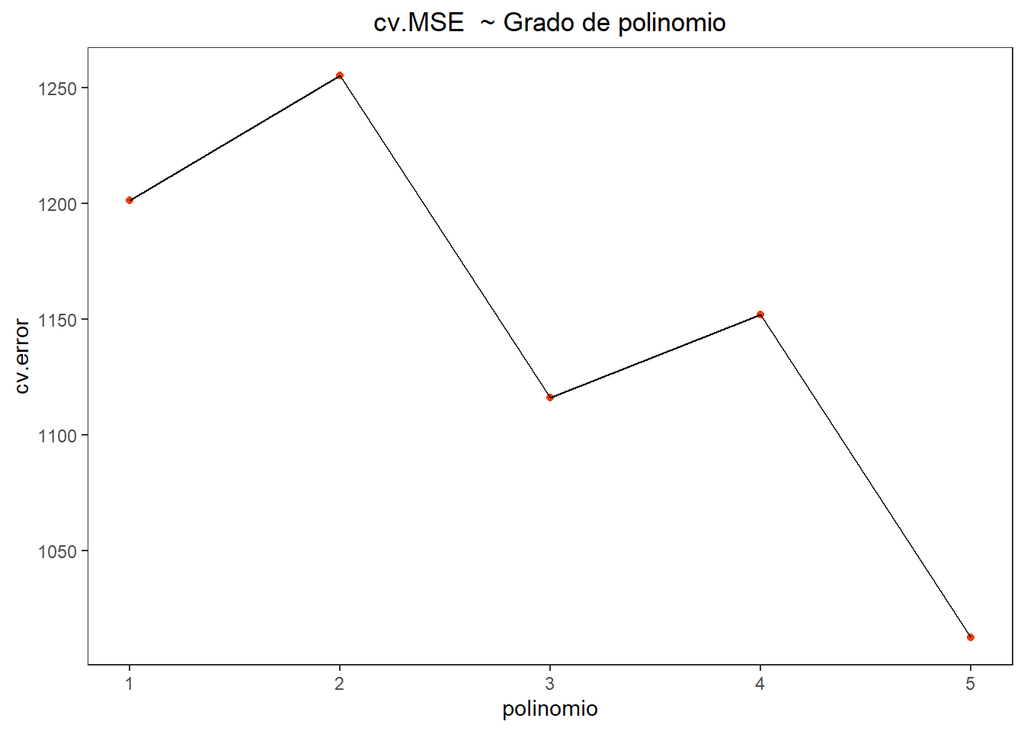

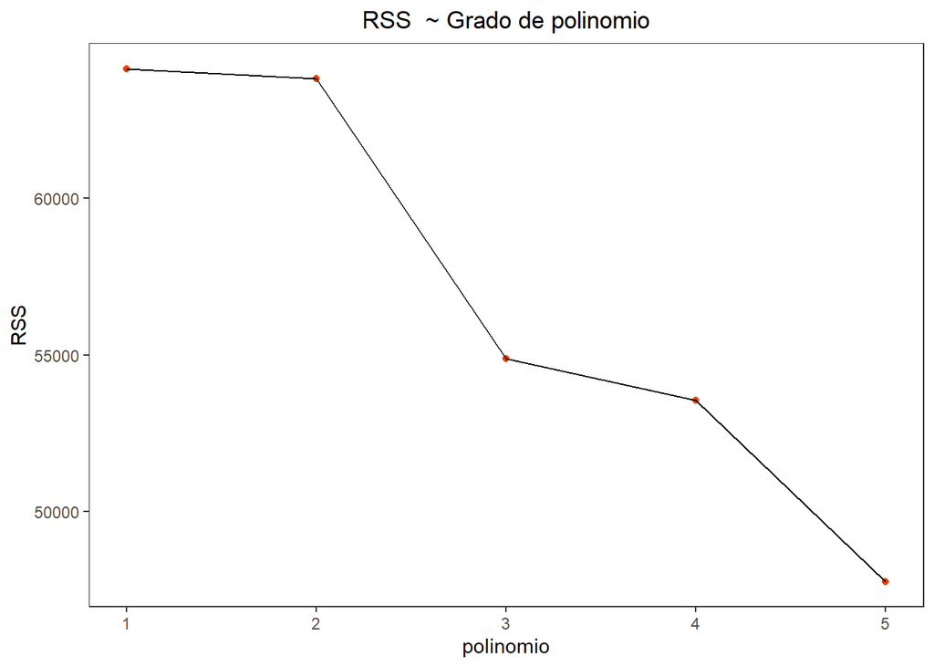

Vemos que el polinomio que mejor ajusta es el de grado 5. Sin embargo, se puede apreciar en la gráfica de error cometido por los ajustes polinómicos que el de grado 3 disminuye bastante el error y tiene un coste computacional menor que el de grado 5. Además, si hacemos un ajuste de grado 5 podríamos estar incurriendo en *overfitting* de los datos. Por ello, en este caso, me quedo con el polinomio cúbico como ajuste.

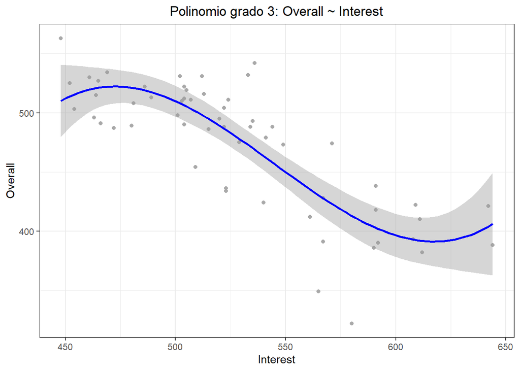

3. `Edu`:

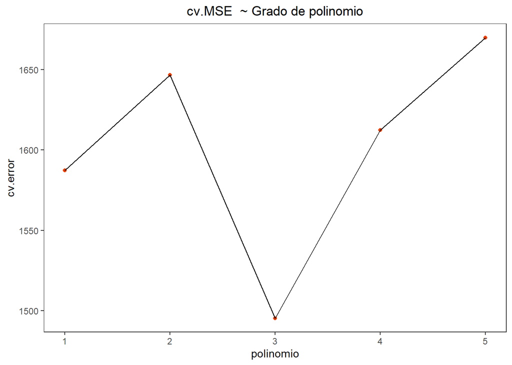

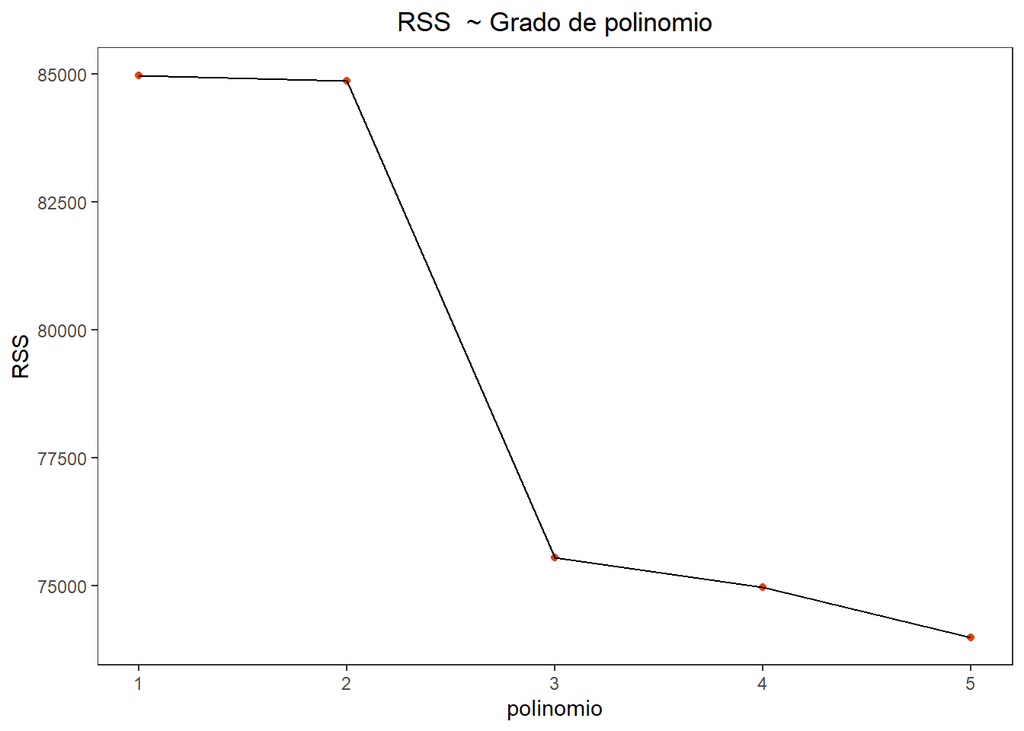

Como ocurróia con `Interest`, me quedo con el ajuste cúbico de `Edu`, obteniendo una gráfica del ajuste como:

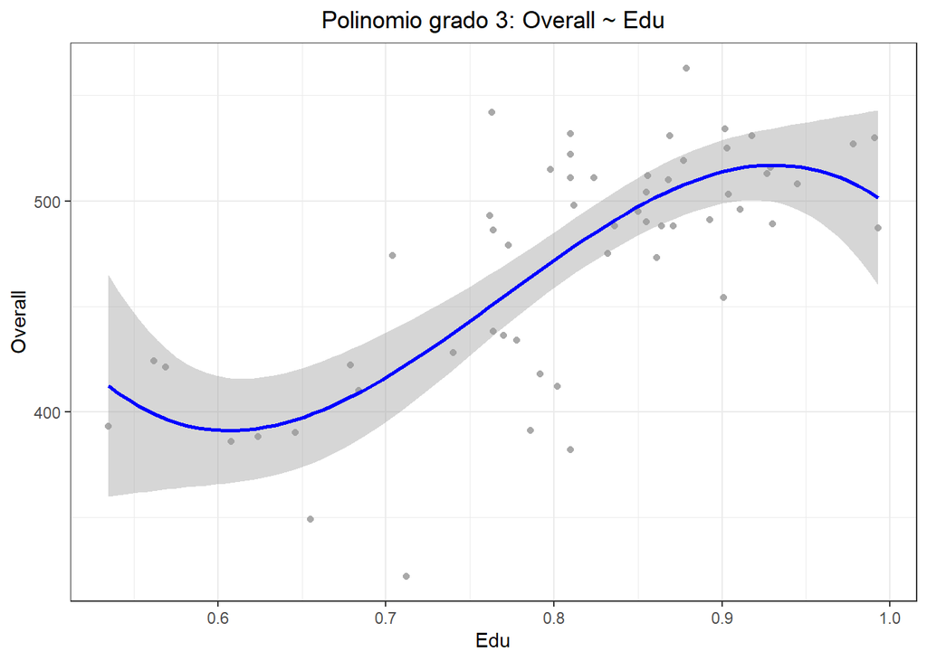

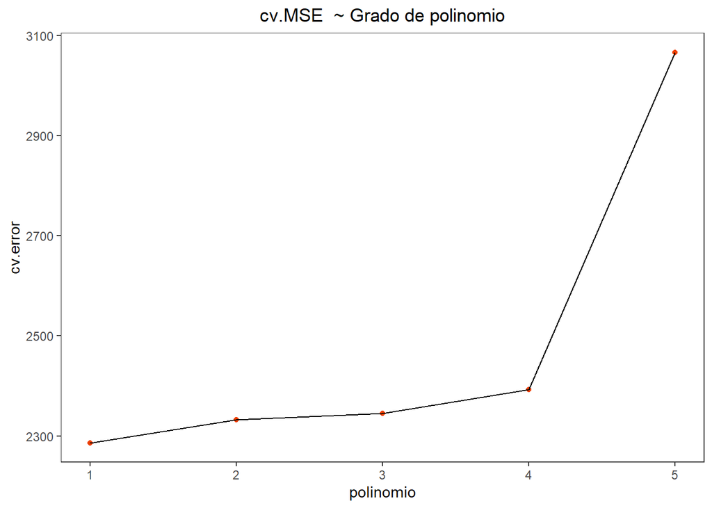

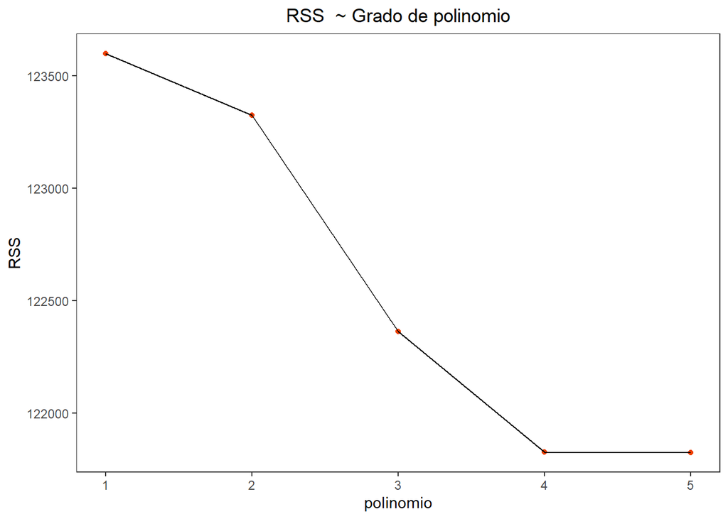

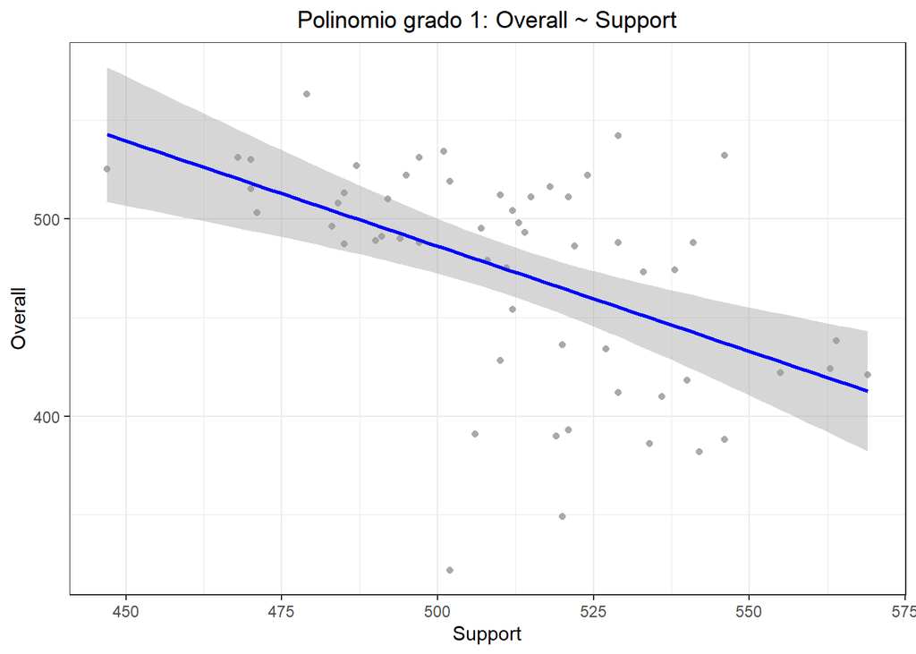

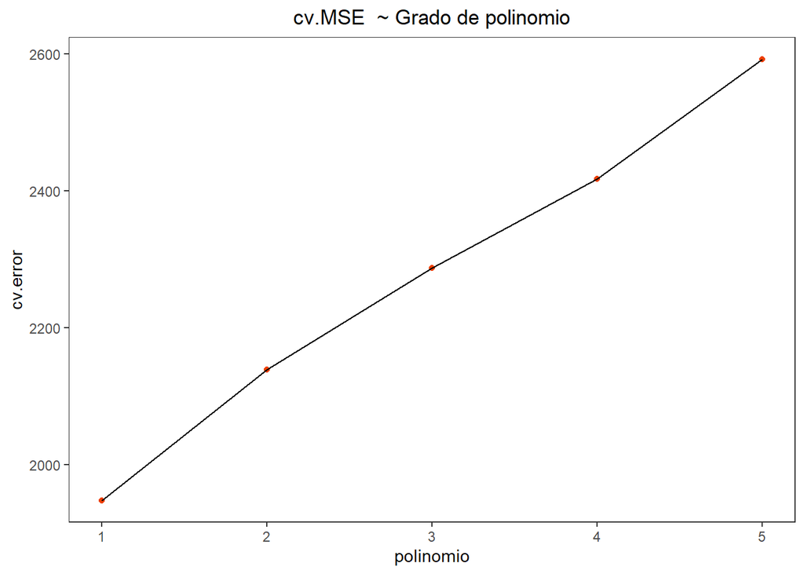

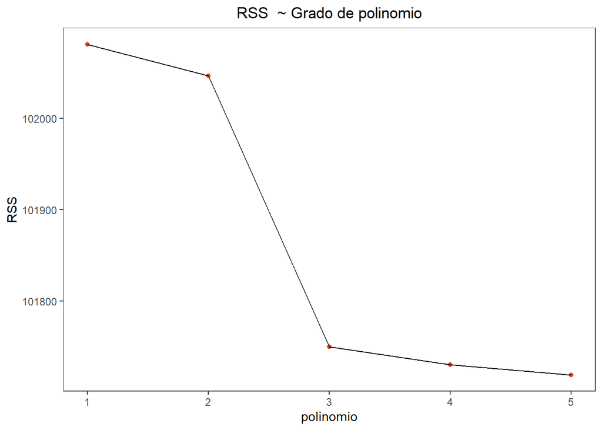

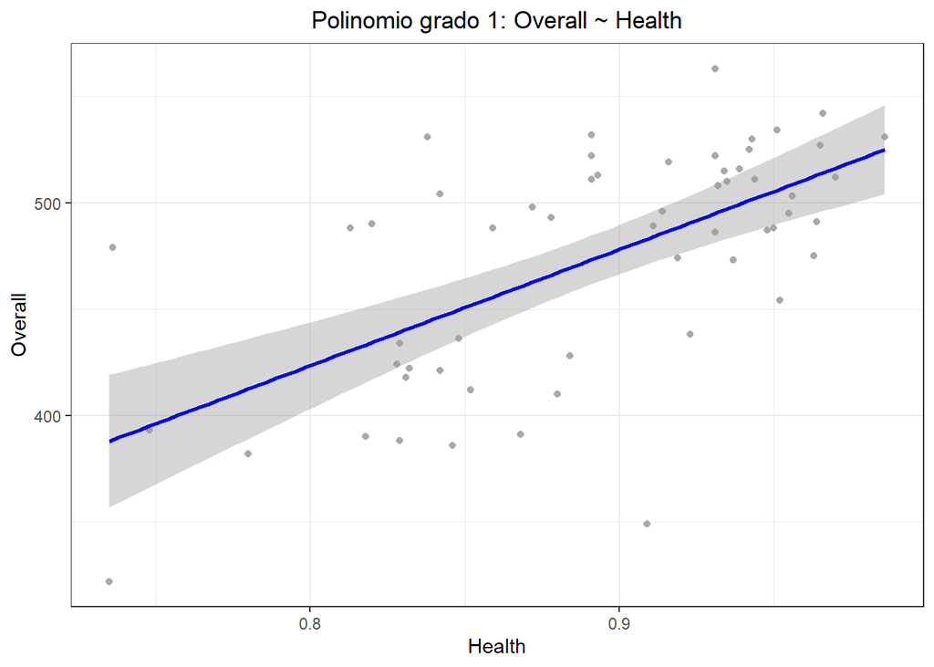

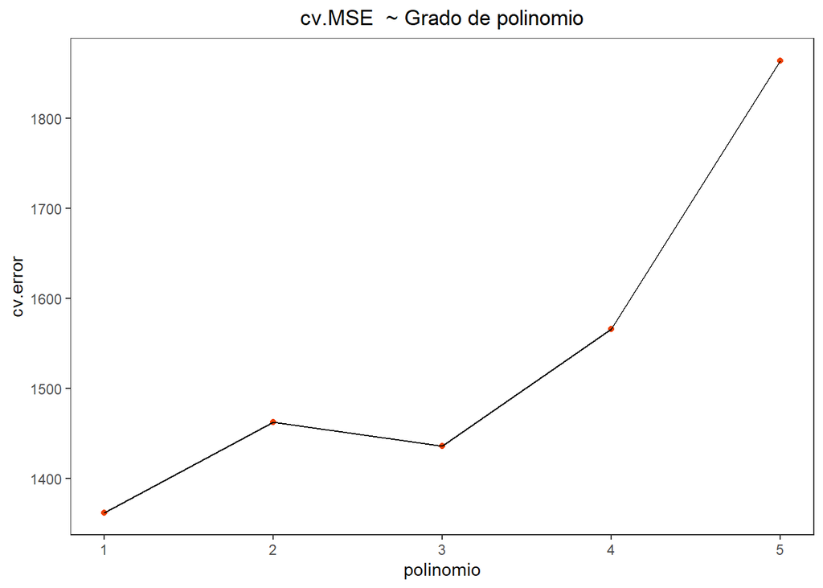

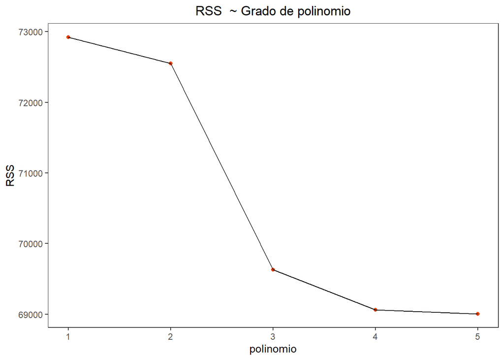

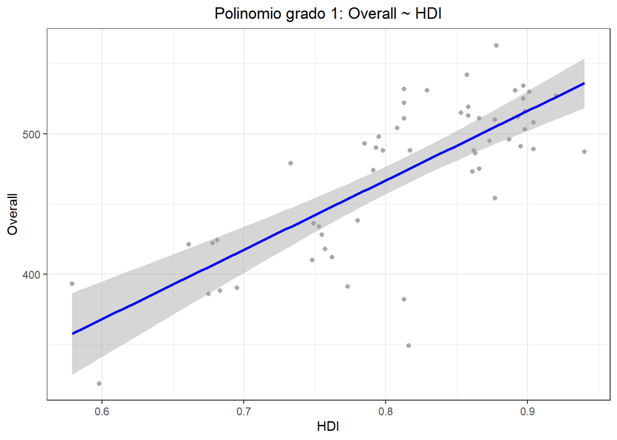

Hemos analizado cuáles serían los modelos que menor error cometen a la hora de hacer el ajuste de las variables frente a `Overall`.

Por tanto, el último modelo de ajuste, lo haremos de la siguiente manera:

- Lineal para: `Support`, `Health`y `HDI`
- Polinómico:

  ```
    - Grado 3: para `Edu` e `Interest`.
    - Grado 2: para `Income`.
  ```

```
##
## Call:
## lm(formula = Overall ~ Support + Health + HDI + poly(Income,
##     2) + poly(Interest, 3) + poly(Edu, 3), data = datos)
##
## Coefficients:
##        (Intercept)             Support              Health                 HDI
##             411.26                0.30              191.96             -323.37
##   poly(Income, 2)1    poly(Income, 2)2  poly(Interest, 3)1  poly(Interest, 3)2
##             141.33              -79.50             -230.76               35.12
## poly(Interest, 3)3       poly(Edu, 3)1       poly(Edu, 3)2       poly(Edu, 3)3
##              49.01              168.81              -30.33              -57.23
```

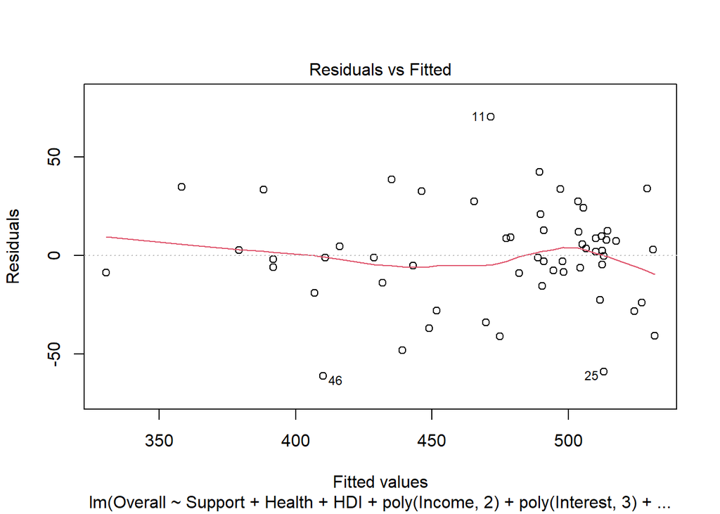

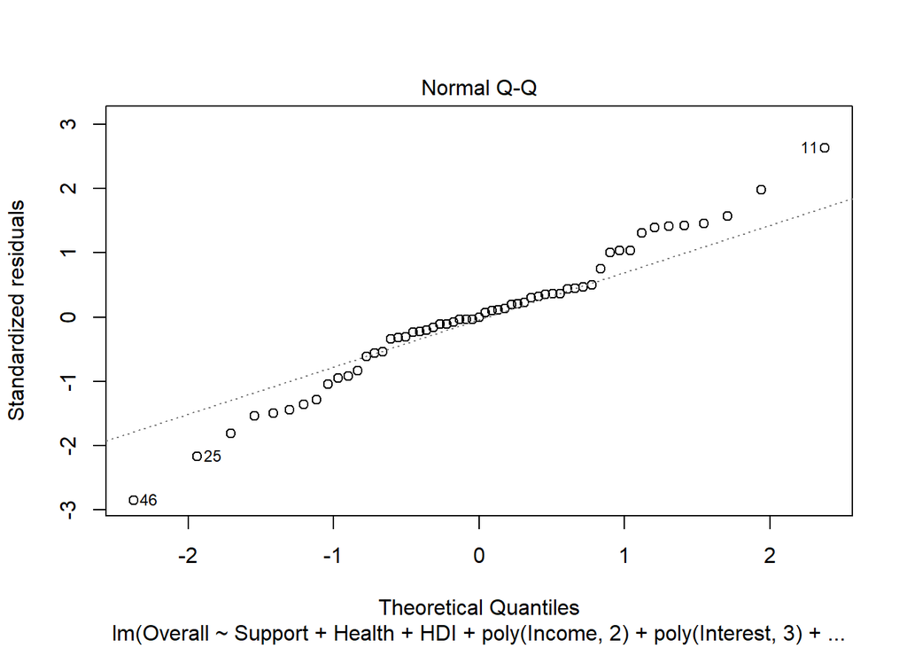

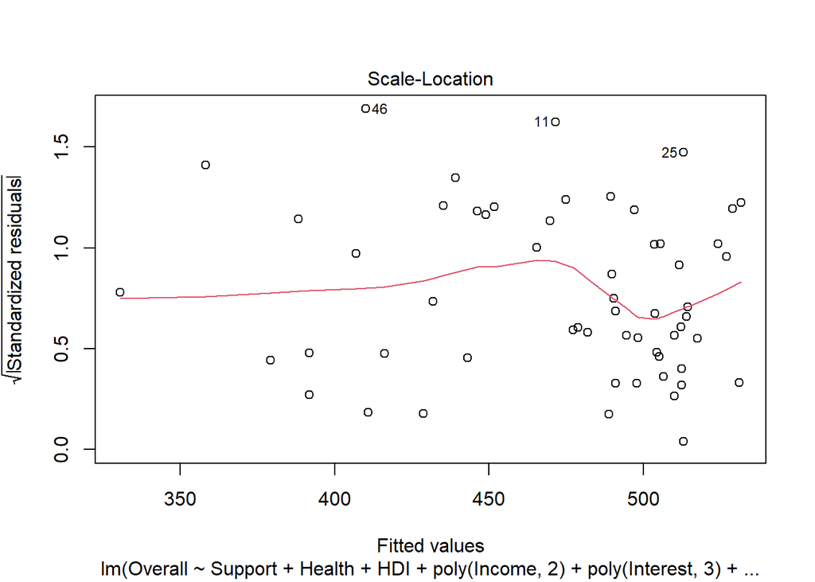

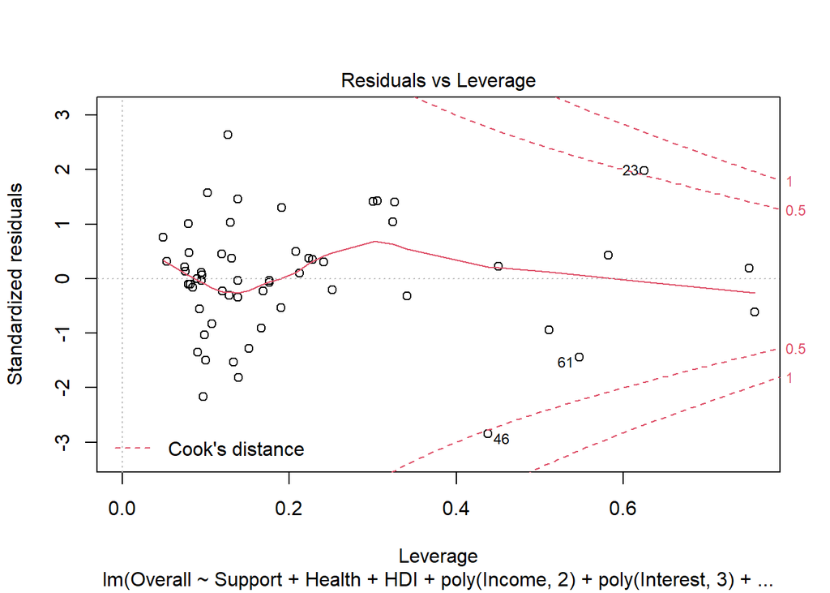

```
##
## Call:
## lm(formula = Overall ~ Support + Health + HDI + poly(Income,
##     2) + poly(Interest, 3) + poly(Edu, 3), data = datos)
##
## Residuals:
##     Min      1Q  Median      3Q     Max
## -61.167  -8.961  -0.043  12.162  70.479
##
## Coefficients:
##                     Estimate Std. Error t value Pr(>|t|)
## (Intercept)         411.2592   227.7577   1.806   0.0777 .
## Support               0.3000     0.2748   1.092   0.2807
## Health              191.9558   140.7563   1.364   0.1794
## HDI                -323.3692   263.0658  -1.229   0.2254
## poly(Income, 2)1    141.3283    94.4261   1.497   0.1415
## poly(Income, 2)2    -79.5003    31.6599  -2.511   0.0157 *
## poly(Interest, 3)1 -230.7626    74.8666  -3.082   0.0035 **
## poly(Interest, 3)2   35.1178    35.3283   0.994   0.3255
## poly(Interest, 3)3   49.0071    31.7732   1.542   0.1300
## poly(Edu, 3)1       168.8139   104.0062   1.623   0.1116
## poly(Edu, 3)2       -30.3268    33.4211  -0.907   0.3690
## poly(Edu, 3)3       -57.2334    31.2292  -1.833   0.0735 .
## ---
## Signif. codes:  0 '***' 0.001 '**' 0.01 '*' 0.05 '.' 0.1 ' ' 1
##
## Residual standard error: 28.6 on 45 degrees of freedom
## Multiple R-squared:  0.7794, Adjusted R-squared:  0.7255
## F-statistic: 14.45 on 11 and 45 DF,  p-value: 2.27e-11
```

```r
anova(modelo_splines, modelo_sin_splines, test = 'F')
```

```
## Analysis of Deviance Table
##
## Model 1: Overall ~ s(Interest) + s(Support) + s(Income) + s(Health) +
##     s(Edu) + s(HDI)
## Model 2: Overall ~ s(Interest) + Support + s(Income) + Health + s(Edu) +
##     HDI
##   Resid. Df Resid. Dev     Df Deviance      F Pr(>F)
## 1    31.194      11013
## 2    30.153      10482 1.0412   531.27 1.5717 0.2205
```

Ejecutamos también los métodos de comparación de modelos AIC y BIC:

```r
AIC(modelo_splines, modelo_sin_splines, modelo_df_manuales, modelo_3)
```

```
##                          df      AIC
## modelo_splines     24.32580 510.4481
## modelo_sin_splines 25.71298 510.4043
## modelo_df_manuales  8.00000 541.4502
## modelo_3           13.00000 556.5599
```

```r
BIC(modelo_splines, modelo_sin_splines, modelo_df_manuales, modelo_3)
```

```
##                          df      BIC
## modelo_splines     24.32580 560.1469
## modelo_sin_splines 25.71298 562.9372
## modelo_df_manuales  8.00000 557.7946
## modelo_3           13.00000 583.1196
```

Vemos que de acuerdo con el criterio AIC debemos escoger el modelo de ajuste que incluye splines en `Interest`, `Income` y `Edu`, y lineales en `Support`, `Health` y `HDI`. Sin embargo, el criterio BIC nos indica que debemos escoger aquel en el que le hemos introducido manualmente los grados de libertad a `Interest`, `Income` y `Edu`. Ambos criterios “descartan” el uso del modelo de ajuste polinómico en virtud de los otros modelos con splines.

Me quedaré con el modelo con menor AIC (`modelo_sin_splines`) porque, además de eso, es el más sencillo de implementar (no es necesario calcular los grados de libertad óptimos previamente).